# Exp2_pilotdata_prolific

Mrudula

20/10/2020

This is the Pilot Data Analysis collected from Prolific for the second version of the Experiment that brought back the distractor words towards the center and the number appears either at the top or bottom.

Loading the libraries and the relevant data files

2. Checking balance in design and all trials and conditions are balanced.

Cleaning data : removing unnecessaary columns, filling Screen background and block count to every cell, splitting the RT column and changed the units to ms and creating a column for Error Rate

Summary of the overall RT

Mean RT

| Min. | 1st Qu. | Median | Mean | 3rd Qu. | Max. |
| --- | --- | --- | --- | --- | --- |
| 335.4 | 490 | 556 | 583.2 | 632 | 1937 |

Accuracy

| 0 | 1 |
| --- | --- |
| 121 | 1799 |

Removing outliers and farouts and showing the summary of RTs for each exclusion criteria

Summary of RT after removing Farouts

| Min. | 1st Qu. | Median | Mean | 3rd Qu. | Max. | NA’s |
| --- | --- | --- | --- | --- | --- | --- |
| 335.4 | 493 | 556 | 571 | 629.5 | 1114 | 160 |

Summary of RT after removing Outliers

| Min. | 1st Qu. | Median | Mean | 3rd Qu. | Max. | NA’s |
| --- | --- | --- | --- | --- | --- | --- |
| 335.4 | 488.5 | 552 | 559.9 | 619.3 | 888 | 214 |

## Analysis of Validity across all trials

```
There are no main effects or an interaction (unlike hiwi pilots) As per the plot it also looks like for test trials, valid trials are faster but for learn valid trials, they are slower. (like the hiwis)
```

- **ANOVA**:

  Table continues below

  | Effect | DFn | DFd | SSn | SSd | F | p | p<.05 |
  | --- | --- | --- | --- | --- | --- | --- | --- |
  | (Intercept) | 1 | 3 | 5205041 | 40196 | 388.5 | 0.0002854 | * |
  | Validity | 1 | 3 | 72.98 | 291.2 | 0.7519 | 0.4497 |  |
  | Condition | 1 | 3 | 289 | 496.4 | 1.747 | 0.278 |  |
  | Validity:Condition | 1 | 3 | 154.9 | 242.1 | 1.92 | 0.2599 |  |

  | ges |
  | --- |
  | 0.9921 |
  | 0.001767 |
  | 0.006963 |
  | 0.003744 |

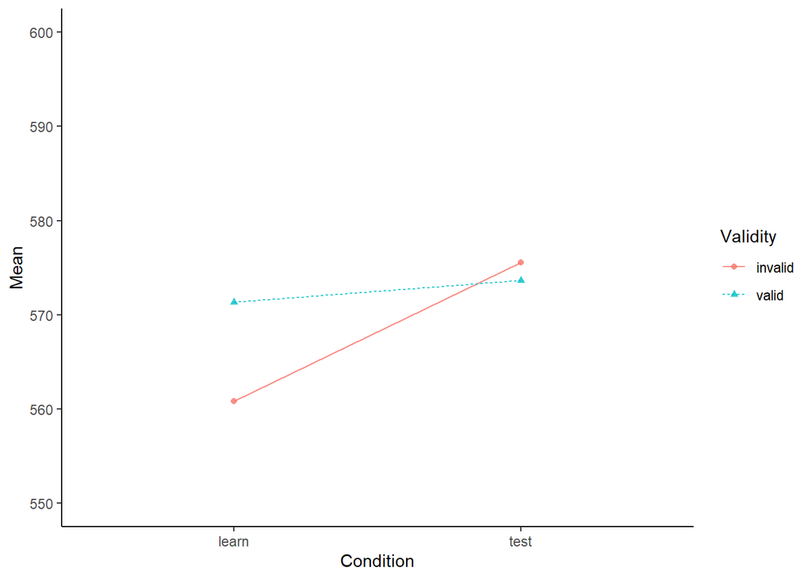

Splitting the data as learn and test trials to analyze individually

```r
Exp2learn_ProlificPilot <- Exp2_ProlificPilot %>%
  filter(Condition == "learn")

Exp2test_ProlificPilot <- Exp2_ProlificPilot %>%
  filter(Condition == "test")

Exp2learn_ProlificPilot<- Exp2learn_ProlificPilot%>%
  mutate(PositionMatch = ifelse(as.character(PositionD)==as.character(PositionT),"same","different"))
```

## Analysis for learn trials

- Farouts

  No significant difference between valid and invalid learn trials

Summary of RTs of valid and invalid trials

| participant | Validity | RT_ifo |
| --- | --- | --- |
| 1 | invalid | 569.8214 |
| 6 | invalid | 491.9466 |
| 7 | invalid | 582.7613 |
| 8 | invalid | 598.9355 |
| 1 | valid | 581.7038 |
| 6 | valid | 481.0341 |
| 7 | valid | 614.9027 |
| 8 | valid | 607.8036 |

```
##
##  Paired t-test
##
## data:  RT_ifo by Validity
## t = -1.1912, df = 3, p-value = 0.3192
## alternative hypothesis: true difference in means is not equal to 0
## 95 percent confidence interval:
##  -38.53270  17.54292
## sample estimates:
## mean of the differences
##               -10.49489
```

- Outliers

  Also no significant difference between valid and invalid learn trials

  ```
  ##
  ##  Paired t-test
  ##
  ## data:  RT_io by Validity
  ## t = -1.0187, df = 3, p-value = 0.3834
  ## alternative hypothesis: true difference in means is not equal to 0
  ## 95 percent confidence interval:
  ##  -19.330127   9.955964
  ## sample estimates:
  ## mean of the differences
  ##               -4.687081
  ```

- Error Rate

  Why is there a difference of significance in error rate (ANOVA vs t test). In the ANOVA it shows as if there is a significant validity effect, but not from the t test.
- **ANOVA**:

  | Effect | DFn | DFd | SSn | SSd | F | p | p<.05 | ges |
  | --- | --- | --- | --- | --- | --- | --- | --- | --- |
  | (Intercept) | 1 | 3 | 0.02508 | 0.008914 | 8.44 | 0.06224 |  | 0.7351 |
  | Validity | 1 | 3 | 0.0006646 | 0.0001251 | 15.94 | 0.02815 | * | 0.06849 |

```
##
##  Paired t-test
##
## data:  ErrorRate by Validity
## t = -0.7624, df = 7, p-value = 0.4707
## alternative hypothesis: true difference in means is not equal to 0
## 95 percent confidence interval:
##  -0.07476825  0.03830992
## sample estimates:
## mean of the differences
##             -0.01822917
```